# Intro to RNA-seq Muddiest Point Review

Jaclyn Taroni for CCDL

2020-05-07

## Introduction

This notebook is designed to address questions that came up in the Introduction to RNA-seq module during CCDL training.

The questions are presented in the order in which they were received, so please take advantage of the table of contents to find and navigate to questions.

- Directory Creation Syntax
- Heatmap Ordering

```r
`%>%` <- dplyr::`%>%`
```

## Directory Creation Syntax

Let’s say we want to create a directory to hold plots that contains subdirectories within it for separate analyses. We’ll call the first analysis `clustering` in the example below.

### `file.path()`

`file.path()` adds a file path separator (`/` on Mac and Linux operating system, which is the operating system that our RStudio Server runs on) between separate folders or directory. Because file path separators can differ between your computer and the computer of someone who wants to use your code, we use `file.path()` instead of typing out `"plots/clustering"`. Each *argument* to `file.path()` is a directory or file name.

```r
file.path("plots", "clustering")
```

```
[1] "plots/clustering"
```

In practice, it can make it easier to change file paths if you update an analysis in the future because you can add an argument to `file.path()`:

```r
file.path("plots", "clustering", "lncRNA")
```

```
[1] "plots/clustering/lncRNA"
```

We can assign the output of `file.path()` to an object.

```r
clustering_dir <- file.path("plots", "clustering")
```

If you assign the output of `file.path()` to an object at the beginning of a script or notebook, when you revisit an analysis or alter an analysis in the future you can take a quick look at the top at your script or notebook and understand where to look for the output. `clustering_dir` in the example above is a character vector of length 1 and behaves the same way as repeating `file.path("plots", "clustering")` anywhere you need it.

### `dir.exists()` and `dir.create()`

`dir.exists()` checks to see whether or not a directory exists. We’ll use it below to demonstrate that `file.path("plots", "clustering")` and `clustering_dir` are equivalent.

```r
dir.exists(file.path("plots", "clustering"))
```

```
[1] FALSE
```

```r
dir.exists(clustering_dir)
```

```
[1] FALSE
```

Creating the `plots/clustering` directory requires us to create two directories: `plots` and the subdirectory `clustering`.

Let’s try creating `clustering_dir` with `dir.create()` without any other arguments.

```r
dir.create(clustering_dir)
```

```
cannot create dir 'plots/clustering', reason 'No such file or directory'
```

Because `plots` doesn’t exist yet, we get an error. If we create `plots` first, we can successfully create `clustering_dir` without any additional arguments.

```r
dir.create("plots")
dir.create(clustering_dir)
```

We see no error and we can check if the directory exists with `dir.exists()` now.

```r
dir.exists(clustering_dir)
```

```
[1] TRUE
```

`dir.create()` has an argument called `recursive` that is `FALSE` by default. Setting `recursive = TRUE` will allow us to more create directories than just the last directory in the path. (In the `clustering_dir` example, the last directory in the path is `clustering`.) Said another way, `recursive = TRUE` allows us to create directories within directories.

Let’s look at another example, a directory called `results/clusters`.

```r
# assign `results/clusters` to a variable using file.path()
cluster_membership_dir <- file.path("results", "clusters")
dir.exists(cluster_membership_dir)
```

```
[1] FALSE
```

`cluster_membership_dir` doesn’t exist yet and consists of the directory `results` and the subdirectory `clusters`, so we can use `dir.create()` with `recursive = TRUE` to create it.

```r
dir.create(cluster_membership_dir, recursive = TRUE)
```

No error, let’s check if the directory exists:

```r
dir.exists(cluster_membership_dir)
```

```
[1] TRUE
```

### Using logicals to create directories

The `!` operator in R negates a logical, so if something is `TRUE` it becomes `FALSE` and vice versa.

```r
!TRUE
```

```
[1] FALSE
```

```r
!FALSE
```

```
[1] TRUE
```

Let’s check for existence of another `results` directory called `pathway_analysis`.

```r
pathway_dir <- file.path("results", "pathway_analysis")
dir.exists(pathway_dir)
```

```
[1] FALSE
```

Since we haven’t created this directory yet, `dir.exists()` returns `FALSE`. Placing `!` in front of this function will negate whatever `dir.exists()` returns.

```r
!dir.exists(pathway_dir)
```

```
[1] TRUE
```

`if` is what we call a conditional statement - it controls the flow of code depending on some check. *If* the condition within the parentheses is true, the code within the curly brackets `{}` will be run.

```r
if (TRUE) {
  # message generates a message
  message("This will run code!")
}
```

```
This will run code!
```

Otherwise, the code within the `{}` will *not* run.

```r
if (FALSE) {
  message("This will run code!")
}
```

No message! Negating a `FALSE` statement will cause the code to run, though.

```r
if (!FALSE) {
  message("This will run code!")
}
```

```
This will run code!
```

Putting this together with the `dir.exists()` - checking for a directory that doesn’t exist yet will cause the code within `{}` to run.

```r
if (!dir.exists(pathway_dir)) {
  message("This will run code!")
}
```

```
This will run code!
```

So we can use this fact to create directories only when we need to. We haven’t created `results/pathway_analysis` yet.

```r
if (!dir.exists(pathway_dir)) {
  dir.create(pathway_dir, recursive = TRUE)
}
```

Now check if the `dir.create()` step was run by checking for existence again:

```r
dir.exists(pathway_dir)
```

```
[1] TRUE
```

And now that it does exist, the code within the `{}` brackets will not run. Let’s demonstrate that with `message()`.

```r
if (!dir.exists(pathway_dir)) {
  message("This will run code!")
}
```

No message.

## Heatmap Ordering

Let’s use the `iris` dataset to demonstrate how to create heatmaps with `pheatmap`.

```r
# Load in the iris data to our workspace
data("iris")
```

The `iris` data frame is already ordered by species.

```r
iris$Species
```

```
  [1] setosa     setosa     setosa     setosa     setosa     setosa     setosa     setosa     setosa
 [10] setosa     setosa     setosa     setosa     setosa     setosa     setosa     setosa     setosa
 [19] setosa     setosa     setosa     setosa     setosa     setosa     setosa     setosa     setosa
 [28] setosa     setosa     setosa     setosa     setosa     setosa     setosa     setosa     setosa
 [37] setosa     setosa     setosa     setosa     setosa     setosa     setosa     setosa     setosa
 [46] setosa     setosa     setosa     setosa     setosa     versicolor versicolor versicolor versicolor
 [55] versicolor versicolor versicolor versicolor versicolor versicolor versicolor versicolor versicolor
 [64] versicolor versicolor versicolor versicolor versicolor versicolor versicolor versicolor versicolor
 [73] versicolor versicolor versicolor versicolor versicolor versicolor versicolor versicolor versicolor
 [82] versicolor versicolor versicolor versicolor versicolor versicolor versicolor versicolor versicolor
 [91] versicolor versicolor versicolor versicolor versicolor versicolor versicolor versicolor versicolor
[100] versicolor virginica  virginica  virginica  virginica  virginica  virginica  virginica  virginica
[109] virginica  virginica  virginica  virginica  virginica  virginica  virginica  virginica  virginica
[118] virginica  virginica  virginica  virginica  virginica  virginica  virginica  virginica  virginica
[127] virginica  virginica  virginica  virginica  virginica  virginica  virginica  virginica  virginica
[136] virginica  virginica  virginica  virginica  virginica  virginica  virginica  virginica  virginica
[145] virginica  virginica  virginica  virginica  virginica  virginica
Levels: setosa versicolor virginica
```

For illustrative purposes, let’s put the data frame in a random order. Then we’ll go through steps to reorder the data frame by species.

```r
# set.seed() allows our shuffling to be reproducible between trials
set.seed(123)
iris_shuffled <- iris[sample(1:nrow(iris), nrow(iris)), ]
```

Let’s look at the first 10 rows of `iris_reshuffled`.

```r
head(iris_shuffled, n = 10)
```

|  | Sepal.Length | Sepal.Width | Petal.Length | Petal.Width | Species |
| --- | --- | --- | --- | --- | --- |
| 14 | 4.3 | 3.0 | 1.1 | 0.1 | setosa |
| 50 | 5.0 | 3.3 | 1.4 | 0.2 | setosa |
| 118 | 7.7 | 3.8 | 6.7 | 2.2 | virginica |
| 43 | 4.4 | 3.2 | 1.3 | 0.2 | setosa |
| 150 | 5.9 | 3.0 | 5.1 | 1.8 | virginica |
| 148 | 6.5 | 3.0 | 5.2 | 2.0 | virginica |
| 90 | 5.5 | 2.5 | 4.0 | 1.3 | versicolor |
| 91 | 5.5 | 2.6 | 4.4 | 1.2 | versicolor |
| 143 | 5.8 | 2.7 | 5.1 | 1.9 | virginica |
| 92 | 6.1 | 3.0 | 4.6 | 1.4 | versicolor |

First use `dplyr::arrange()` to order by the `Species` column. If we want to specify an order that is not alphabetical, we can change the order of levels in the `Species` column with `dplyr::mutate()` and the `levels` argument to `factor()`.

```r
iris_shuffled <- iris_shuffled %>%
  dplyr::mutate(Species = factor(Species,
                                 levels = c("versicolor",
                                            "setosa",
                                            "virginica"))) %>%
  dplyr::arrange(Species)
```

Let’s look at the order of the `Species` column now.

```r
iris_shuffled$Species
```

```
  [1] versicolor versicolor versicolor versicolor versicolor versicolor versicolor versicolor versicolor
 [10] versicolor versicolor versicolor versicolor versicolor versicolor versicolor versicolor versicolor
 [19] versicolor versicolor versicolor versicolor versicolor versicolor versicolor versicolor versicolor
 [28] versicolor versicolor versicolor versicolor versicolor versicolor versicolor versicolor versicolor
 [37] versicolor versicolor versicolor versicolor versicolor versicolor versicolor versicolor versicolor
 [46] versicolor versicolor versicolor versicolor versicolor setosa     setosa     setosa     setosa
 [55] setosa     setosa     setosa     setosa     setosa     setosa     setosa     setosa     setosa
 [64] setosa     setosa     setosa     setosa     setosa     setosa     setosa     setosa     setosa
 [73] setosa     setosa     setosa     setosa     setosa     setosa     setosa     setosa     setosa
 [82] setosa     setosa     setosa     setosa     setosa     setosa     setosa     setosa     setosa
 [91] setosa     setosa     setosa     setosa     setosa     setosa     setosa     setosa     setosa
[100] setosa     virginica  virginica  virginica  virginica  virginica  virginica  virginica  virginica
[109] virginica  virginica  virginica  virginica  virginica  virginica  virginica  virginica  virginica
[118] virginica  virginica  virginica  virginica  virginica  virginica  virginica  virginica  virginica
[127] virginica  virginica  virginica  virginica  virginica  virginica  virginica  virginica  virginica
[136] virginica  virginica  virginica  virginica  virginica  virginica  virginica  virginica  virginica
[145] virginica  virginica  virginica  virginica  virginica  virginica
Levels: versicolor setosa virginica
```

We’ll drop the `Species` column for the heatmap itself. To retain the row ordering by `Species`, we need to set `cluster_rows` to `FALSE`. These plant samples don’t have sample names, just numbers. We’ll remove the row labels with the `show_rownames` argument.

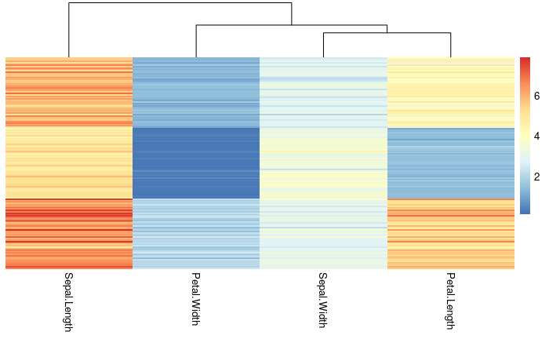

```r
pheatmap::pheatmap(iris_shuffled %>% dplyr::select(-Species),
                   cluster_rows = FALSE,
                   show_rownames = FALSE)
```

To order the columns in a specific way, we can use `dplyr::select()`. (This command will also drop `Species` just because we don’t include it!)

```r
iris_shuffled %>%
  dplyr::select(Petal.Width,
                Petal.Length,
                Sepal.Width,
                Sepal.Length)
```

| Petal.Width | Petal.Length | Sepal.Width | Sepal.Length |
| --- | --- | --- | --- |
| 1.3 | 4.0 | 2.5 | 5.5 |
| 1.2 | 4.4 | 2.6 | 5.5 |
| 1.4 | 4.6 | 3.0 | 6.1 |
| 1.1 | 3.0 | 2.5 | 5.1 |
| 1.3 | 4.0 | 2.8 | 6.1 |
| 1.7 | 5.0 | 3.0 | 6.7 |
| 1.1 | 3.8 | 2.4 | 5.5 |
| 1.4 | 4.4 | 3.0 | 6.6 |
| 1.2 | 4.7 | 2.8 | 6.1 |
| 1.4 | 3.9 | 2.7 | 5.2 |

[output cut: 140 more lines]

Or by using square brackets and a character vector that matches the column names.

```r
ordered_column_names <- c("Petal.Width",
                          "Petal.Length",
                          "Sepal.Width",
                          "Sepal.Length")
iris_shuffled[, ordered_column_names]
```

| Petal.Width | Petal.Length | Sepal.Width | Sepal.Length |
| --- | --- | --- | --- |
| 1.3 | 4.0 | 2.5 | 5.5 |
| 1.2 | 4.4 | 2.6 | 5.5 |
| 1.4 | 4.6 | 3.0 | 6.1 |
| 1.1 | 3.0 | 2.5 | 5.1 |
| 1.3 | 4.0 | 2.8 | 6.1 |
| 1.7 | 5.0 | 3.0 | 6.7 |
| 1.1 | 3.8 | 2.4 | 5.5 |
| 1.4 | 4.4 | 3.0 | 6.6 |
| 1.2 | 4.7 | 2.8 | 6.1 |
| 1.4 | 3.9 | 2.7 | 5.2 |

[output cut: 140 more lines]

Now let’s create a heatmap with our specified column order: `Petal.Width`, `Petal.Length`, `Sepal.Width`, `Sepal.Length`. AND retain our ordering by `Species` – `iris_shuffled` is already ordered by `Species`. We need to set both `cluster_cols` AND `cluster_rows` to `FALSE`.

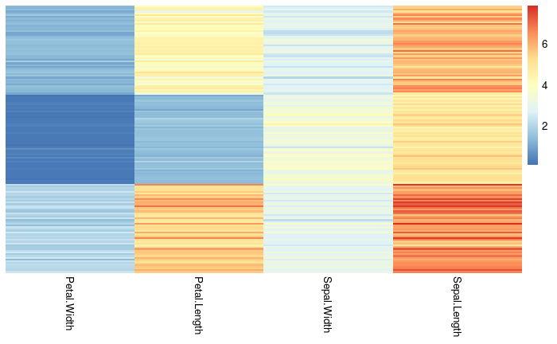

```r
pheatmap::pheatmap(iris_shuffled[, ordered_column_names],
                   cluster_cols = FALSE,
                   cluster_rows = FALSE,
                   show_rownames = FALSE)
```

### Heatmap annotation

It can be helpful to include annotations for your rows or columns in your heatmaps. Here we’ll use row and column annotations to indicate species and what part of the irises are being measured (petal or sepal), respectively.

Our first step is to generate data frames for each annotation.

```r
# Column annotation - we will order the heatmap columns with
# ordered_column_names again so we need to take that into account when we
# build the column annotation
annotation_column <- data.frame(
  # take a look at ?rep for a shortcut/handy function we could use here
  flower_part = c("Petal", "Petal", "Sepal", "Sepal")
)
# The annotation data frames need rownames
rownames(annotation_column) <- ordered_column_names

# Row annotation - we can use the Species column from the iris data frame
# itself
annotation_row <- data.frame(
  species = iris_shuffled$Species
)
# Without "proper" rownames (e.g., not just numbers) in the iris data.frame,
# the row annotation gives us an error
rownames(iris_shuffled) <- paste0("iris", rownames(iris_shuffled))
rownames(annotation_row) <- rownames(iris_shuffled)
```

Let’s create a heatmap using the annotation data frames.

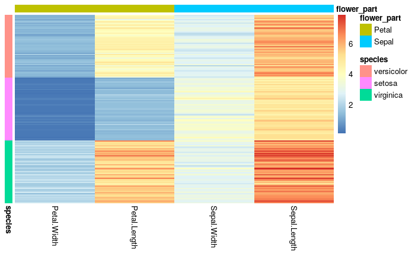

```r
pheatmap::pheatmap(iris_shuffled[, ordered_column_names],
                   cluster_cols = FALSE,
                   cluster_rows = FALSE,
                   show_rownames = FALSE,
                   annotation_col = annotation_column,
                   annotation_row = annotation_row)
```

We also have the ability to control the colors we use for the annotations.

```r
# The names in this list, including the names of the vectors that make up the
# elements of the list, need to perfectly match what is in annotation_column
# and annotation_row
annotation_colors <- list(
  # Here we're using hexcodes to specify colors, rather than their names in R
  # This can be helpful if you're using programs * other than R * to generate
  # display items for a paper/project
  species = c(versicolor = "#E69F00",
              setosa = "#56B4E9",
              virginica = "#009E73"),
  flower_part = c(Petal = "#0072B2",
                  Sepal = "#F0E442")
)
```

Now let’s use our custom annotation colors in our heatmap.

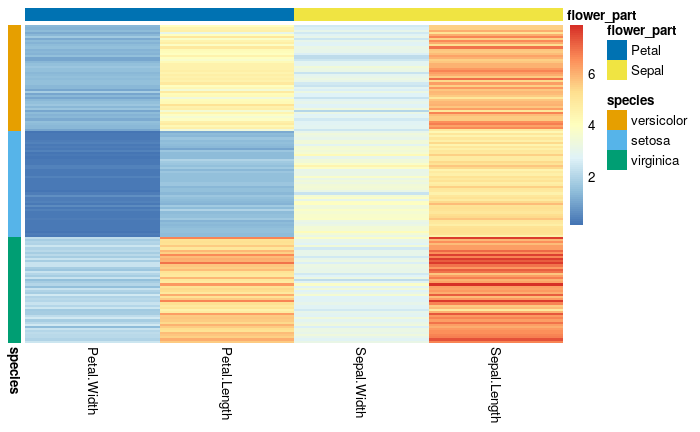

```r
pheatmap::pheatmap(iris_shuffled[, ordered_column_names],
                   cluster_cols = FALSE,
                   cluster_rows = FALSE,
                   show_rownames = FALSE,
                   annotation_col = annotation_column,
                   annotation_row = annotation_row,
                   annotation_colors = annotation_colors)
```